# Quanifying the User Experience

## Analyzing Survey Data with Python for Beginners

Mixed-method approaches to UX research are becoming increasingly popular, utlilizing both quantitative & qualitative research methods. Surveying is a popular quantitative method that can quickly and easily gauge the representativeness of individual views and experiences and is often paired with qualitative research methods.

This documemnt serves as a brief guide into how you can quickly analyze survey data with multiple types of data using Python. You can follow along using this computational notebook, [JuypterLab](https://mybinder.org/v2/gh/jupyterlab/jupyterlab-demo/master?urlpath=lab/tree/demo).

## Surveying Practices

Survey data can be collected using a number of surveying tools to include, but not limited to [Google Forms](https://www.google.com/forms/about/), [Typeform](https://www.typeform.com/), [SurveyMonkey](https://www.surveymonkey.com/). Once you've administed your survey and collected all responses, the collected data can be exported as a CSV or XLSX file and ready for Python import.

## The Data Set

The dataset used in this tutorial is from a survey meant to evlaute the tools & processes used in UX across Africa. This study collected demographic and experience information. The dataset we will use in this tutorial contains mutiple and single choice questioning. If you would like to follow along using this same dataset you can find it [here](http://www.google.com/drive).

# Analyzing Data

## Pandas

Pandas is a powerful Python library used to analyze and manipulate numeric and time series data. The following code imports Python's Pandas library and assigns it's future notation as *pd*.

```python
import pandas as pd
```

### Importing data as a DataFrame

The following code imports the referenced XLSX file as a DataFrame; assigning it the variable *df*.

> *A dataFrame is a structure that contains two-dimensional data and its corresponding labels similar to the spreadsheets that you work with in Excel. These types of data structures are widley used many data-intensive fields like data science or machine learning.*

```python
df = pd.read_excel (r'/Users/imaurimotorin/Downloads/stateofux.xlsx', sheet_name='clean-data')
```

## Getting a read on you data

You can use the `.head` and `.shape` properties to gather information about your dataset. `.head` previews the dataset and `.shape` gives you the number of columns and rows in the dataset.

```python
df.head(5)
```

|  | Timestamp | Name | Email | Country | Organization | Type of Organization | Organization Size | Sector | Respondent's Role | Respondent's Level of Experience | ... | Who Conducts Research | Research Frequency/year.1 | Type of Research.1 | Tools for UX Research | Tools for Collaboration and Brainstorming | Tools for UX/Web Analytics | Tools for UI Design | Stage of the Pesign Process needs Tools adapted for the African Context | Open to YUX Interview? | Name Included in Report |
| --- | --- | --- | --- | --- | --- | --- | --- | --- | --- | --- | --- | --- | --- | --- | --- | --- | --- | --- | --- | --- | --- |
| 0 | 6/10/2021 11:20:15 | Hamidius | hamadamidi9@gmail.com | Senegal | hui-designers | Service-based company or agency | Less than 10 people | Fintech, Agritech, Edtech, Media, Healthtech | UX/UI Designer | Mid-level | ... | UX/UI Designer, Product Manager, Marketing team | Twice | User and Usability Testing | Calendly, Typeform, Notion, Doodle | Miro, Google Docs, Mural | Google Analytics | Figma, Sketch, InVision | NaN | Yes | Yes |
| 1 | 6/10/2021 11:23:37 | Stephen Doe | donsimon505@gmail.com | Ghana | Kofie | Service-based company or agency | Less than 10 people | Media, Digital Consulting | Web Developer | Entry level | ... | No one conducts research | Once | UX/Web Analytics | Forms on our website | Miro, Slack | Google Analytics | Adobe XD | NaN | No | Yes |
| 2 | 6/10/2021 12:32:54 | Michael Senyonjo | gdmichael4@gmail.com | Uganda | M-KOPA | Product-based company or start-up | More than 250 people | Fintech | Researcher & UI/UX design | Senior | ... | UX/UI Designer | Three or more times | All the above | Notion, Microsoft Forms, Maze | Miro, Notion, Microsoft Teams | Amplitude, Google Analytics | Figma | Research mostly. Tools that can help participa... | Yes | Yes |
| 3 | 6/10/2021 12:58:11 | Camille Courbariaux- Kramer | camille@yux.design | Senegal | YUX | Service-based company or agency | 20 - 49 people | Design | Academy lead | Senior | ... | NaN | NaN | NaN | Notion | Miro, Notion, Google Docs | Google Analytics | Figma, Sketch, InVision | research! | Yes | Yes |
| 4 | 6/10/2021 13:13:40 | Ibrahima Fall | ibrahima1055@yahoo.co.uk | Senegal | Go my code | Product-based company or start-up | More than 250 people | Edtech | UX/UI Designer | Mid-level | ... | UX/UI Designer | Once | Individual Interviews | Google Forms | Miro | Google Analytics | Figma | Research | Yes | Yes |

5 rows × 27 columns

```python
df.shape
```

```
(100, 27)
```

## Data Cleansing (Coming Soon)

*Survey data can be messy.*

# Identifying data complexities

Once your data is imported you will want to catagorize all entries with similar input types. This will make it easier to manipluate and analyze similarily structured sets of data. Here I make an array, identifying the columns [names] with muliple entries (1: car, train, bus) and those with single values (3 :bus).

```python
multi_v_cols = ['Sector',
                'Type of Research',
                'Tools for Collaboration and Brainstorming',
                'Tools for UX/Web Analytics',
                'Tools for UI Design',
                'Challenges Conducting UX Research or Design in Africa',
                'Who Conducts Research',
                'Tools for UX Research'
               ]
single_v_cols = [ 'Type of Organization',
                'Country',
                'Organization Size',
                'Respondent\'s Role',
                'Respondent\'s Level of Experience',
                '# of Designers in your Organization',
                'Dedicated Researchers (Yes/No)',
                '# of UX Researchers in your Organization',
                'Research Frequency/year'
                ]
```

### Tallying Multi-valued Data

The following function runs through all the columns that are multivalued (multi_v_cols) and applies the following functions: `.explode` transforms each element of a list-like to a row, replicating index values. `.value_count` counts each time a value occurs, and `.strip` cleans the data and clears the white space.

These survey questions not only gave respondence the option to select multiple values, but some also gave respondence the option to provide a short written response if their desired response was not listed. Using the methods listed above, unique and identifical written values were tallied as well.

The following code also visualized the tallied data as pie charts and percentages using a library called Matplot, denoted as *plt*.

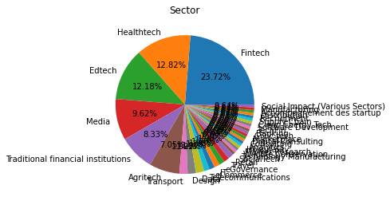

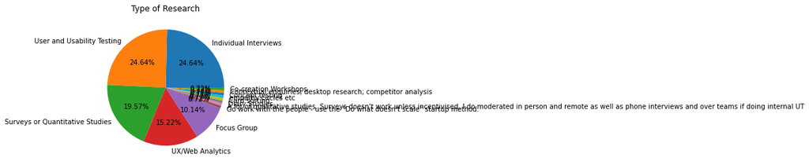

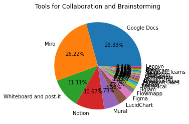

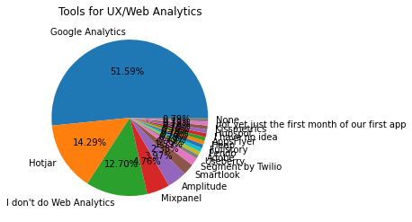

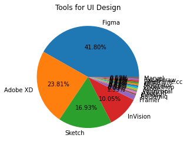

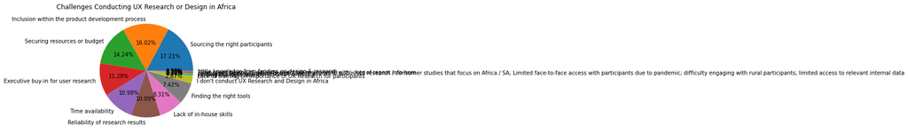

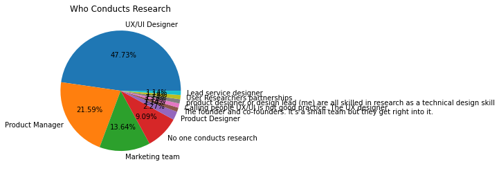

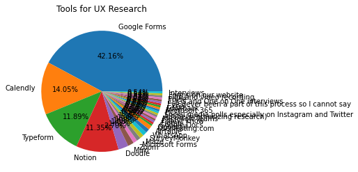

```python
import pylab
import matplotlib.pyplot as plt

for col in multi_v_cols:
    col_data = df[col]
    col_data.str.split(',')\
        .explode(ignore_index = True)\
        .str.strip()\
        .value_counts()\
        .plot(kind="pie", autopct='%1.2f%%')\


    pylab.ylabel('')
    plt.title(col)
    plt.show()
```

## Correlations & Data Relationships

Next, I make of copy of the data in order to ensure the integrity of the orginal data source during manipulation and for reference to the final dataframe. Again using the `.explode` function each element is translated into a list.

```python
df3 = df.copy()
for col in multi_v_cols:
    df3 = df3.explode(col)

ignore_cols = ['Timestamp', 'Name', 'Email', 'Organization', 'Name Included in Report', 'Open to YUX Interview?', 'Stage of the Pesign Process needs Tools adapted for the African Context', 'Research Frequency/year.1', 'Challenges Developing Products in Africa', 'Type of Research.1']

# Remove columsn with multiple values from original dataframe
df_dropped = df.drop(ignore_cols, axis=1)

# One-Hot Encode the dataframe
df_2 = pd.get_dummies(df_dropped, drop_first=True)

# Create a copy to modify into final dataframe
df_final = df_2.copy()

# Loop through the columns with multiple values
for col in multi_v_cols:
  df_3 = df[col].str.get_dummies(sep=',') # One-Hot Encode with sep param
  df_3.columns = [f'{col}_{c}' for c in df_3.columns] # Rename columns to include the original column name
  df_final = pd.concat([df_final, df_3],axis=1) # Append the new dataframe to the final dataframe

# Get Correlation
display(df_final.corr())
df_final.corr().to_csv(r'/Users/imaurimotorin/Downloads/correlation_per_response.csv', index = True)
```

|  | Country_Cameroon | Country_Democratic Republic of the Congo | Country_Ethiopia | Country_Ghana | Country_Ivory Coast | Country_Kenya | Country_Mali | Country_Mauritius | Country_Mozambique | Country_Nigeria | ... | Tools for UX Research_Google Forms | Tools for UX Research_I don't know | Tools for UX Research_I've never been a part of this process so I cannot say | Tools for UX Research_Interviews | Tools for UX Research_Microsoft 365 | Tools for UX Research_Microsoft Forms | Tools for UX Research_Microsoft Teams | Tools for UX Research_Notion | Tools for UX Research_Pulse | Tools for UX Research_Social media polls especially on Instagram and Twitter |
| --- | --- | --- | --- | --- | --- | --- | --- | --- | --- | --- | --- | --- | --- | --- | --- | --- | --- | --- | --- | --- | --- |
| Country_Cameroon | 1.000000 | -0.014358 | -0.014358 | -0.039193 | -0.014358 | -0.078077 | -0.014358 | -0.014358 | -0.014358 | -0.069189 | ... | -0.020199 | -0.014358 | -0.014358 | -0.014358 | -0.014358 | -0.014358 | -0.014358 | -0.025123 | -0.014358 | -0.014358 |
| Country_Democratic Republic of the Congo | -0.014358 | 1.000000 | -0.010101 | -0.027573 | -0.010101 | -0.054929 | -0.010101 | -0.010101 | -0.010101 | -0.048676 | ... | 0.087293 | -0.010101 | -0.010101 | -0.010101 | -0.010101 | -0.010101 | -0.010101 | -0.017675 | -0.010101 | -0.010101 |
| Country_Ethiopia | -0.014358 | -0.010101 | 1.000000 | -0.027573 | -0.010101 | -0.054929 | -0.010101 | -0.010101 | -0.010101 | -0.048676 | ... | -0.115714 | -0.010101 | -0.010101 | -0.010101 | -0.010101 | -0.010101 | -0.010101 | -0.017675 | -0.010101 | -0.010101 |
| Country_Ghana | -0.039193 | -0.027573 | -0.027573 | 1.000000 | -0.027573 | -0.149943 | -0.027573 | -0.027573 | -0.027573 | -0.132875 | ... | 0.000792 | -0.027573 | -0.027573 | -0.027573 | -0.027573 | -0.027573 | -0.027573 | -0.048248 | -0.027573 | -0.027573 |
| Country_Ivory Coast | -0.014358 | -0.010101 | -0.010101 | -0.027573 | 1.000000 | -0.054929 | -0.010101 | -0.010101 | -0.010101 | -0.048676 | ... | -0.115714 | -0.010101 | -0.010101 | -0.010101 | -0.010101 | 1.000000 | -0.010101 | -0.017675 | -0.010101 | -0.010101 |
| ... | ... | ... | ... | ... | ... | ... | ... | ... | ... | ... | ... | ... | ... | ... | ... | ... | ... | ... | ... | ... | ... |
| Tools for UX Research_Microsoft Forms | -0.014358 | -0.010101 | -0.010101 | -0.027573 | 1.000000 | -0.054929 | -0.010101 | -0.010101 | -0.010101 | -0.048676 | ... | -0.115714 | -0.010101 | -0.010101 | -0.010101 | -0.010101 | 1.000000 | -0.010101 | -0.017675 | -0.010101 | -0.010101 |
| Tools for UX Research_Microsoft Teams | -0.014358 | -0.010101 | -0.010101 | -0.027573 | -0.010101 | -0.054929 | -0.010101 | -0.010101 | 1.000000 | -0.048676 | ... | -0.115714 | -0.010101 | -0.010101 | -0.010101 | -0.010101 | -0.010101 | 1.000000 | -0.017675 | -0.010101 | -0.010101 |
| Tools for UX Research_Notion | -0.025123 | -0.017675 | -0.017675 | -0.048248 | -0.017675 | -0.096115 | -0.017675 | -0.017675 | -0.017675 | -0.085174 | ... | -0.202478 | -0.017675 | -0.017675 | -0.017675 | -0.017675 | -0.017675 | -0.017675 | 1.000000 | -0.017675 | -0.017675 |
| Tools for UX Research_Pulse | -0.014358 | -0.010101 | -0.010101 | -0.027573 | -0.010101 | -0.054929 | -0.010101 | -0.010101 | -0.010101 | -0.048676 | ... | -0.115714 | -0.010101 | -0.010101 | -0.010101 | -0.010101 | -0.010101 | -0.010101 | -0.017675 | 1.000000 | -0.010101 |
| Tools for UX Research_Social media polls especially on Instagram and Twitter | -0.014358 | -0.010101 | -0.010101 | -0.027573 | -0.010101 | -0.054929 | -0.010101 | -0.010101 | -0.010101 | -0.048676 | ... | -0.115714 | -0.010101 | -0.010101 | -0.010101 | -0.010101 | -0.010101 | -0.010101 | -0.017675 | -0.010101 | 1.000000 |

540 rows × 540 columns

|  | Country | Type of Organization | Organization Size | Sector | Respondent's Role | Respondent's Level of Experience | Challenges Conducting UX Research or Design in Africa | # of Designers in your Organization | Dedicated Researchers (Yes/No) | # of UX Researchers in your Organization | Research Frequency/year | Type of Research | Who Conducts Research | Tools for UX Research | Tools for Collaboration and Brainstorming | Tools for UX/Web Analytics | Tools for UI Design |
| --- | --- | --- | --- | --- | --- | --- | --- | --- | --- | --- | --- | --- | --- | --- | --- | --- | --- |
| Country | 1.000000 | -0.119024 | 0.026080 | 0.089842 | -0.074796 | 0.137034 | 0.210624 | 0.110875 | -0.182822 | 0.150273 | 0.152451 | 0.167767 | -0.070688 | 0.064015 | -0.134183 | -0.049470 | 0.145850 |
| Type of Organization | -0.119024 | 1.000000 | 0.009542 | 0.167681 | 0.017659 | -0.138829 | 0.010714 | -0.058505 | 0.116114 | -0.102620 | -0.134905 | -0.140047 | -0.064801 | -0.105698 | 0.076131 | 0.002034 | -0.040204 |
| Organization Size | 0.026080 | 0.009542 | 1.000000 | 0.114237 | 0.014743 | 0.161913 | -0.011257 | 0.204575 | 0.065433 | -0.087513 | -0.080381 | -0.081224 | -0.075017 | 0.003076 | -0.051685 | -0.044281 | 0.212480 |
| Sector | 0.089842 | 0.167681 | 0.114237 | 1.000000 | -0.073906 | 0.115149 | -0.190165 | -0.115542 | -0.044883 | -0.025692 | 0.018305 | 0.167770 | -0.030657 | 0.149985 | -0.023777 | 0.004548 | 0.132383 |
| Respondent's Role | -0.074796 | 0.017659 | 0.014743 | -0.073906 | 1.000000 | -0.145140 | -0.015401 | 0.023893 | 0.023052 | -0.031945 | -0.052014 | -0.001424 | 0.079107 | -0.079042 | -0.027687 | 0.026256 | -0.130584 |
| Respondent's Level of Experience | 0.137034 | -0.138829 | 0.161913 | 0.115149 | -0.145140 | 1.000000 | -0.019416 | 0.089515 | 0.086343 | -0.139774 | -0.057936 | 0.025742 | -0.020769 | 0.185032 | -0.167584 | -0.205608 | 0.099710 |
| Challenges Conducting UX Research or Design in Africa | 0.210624 | 0.010714 | -0.011257 | -0.190165 | -0.015401 | -0.019416 | 1.000000 | 0.250274 | 0.034883 | 0.000282 | -0.044317 | -0.030838 | -0.020674 | -0.019094 | -0.090724 | 0.001264 | 0.118249 |
| # of Designers in your Organization | 0.110875 | -0.058505 | 0.204575 | -0.115542 | 0.023893 | 0.089515 | 0.250274 | 1.000000 | 0.266767 | -0.145062 | -0.270432 | -0.304323 | -0.118363 | -0.067589 | -0.041497 | 0.018128 | 0.178284 |
| Dedicated Researchers (Yes/No) | -0.182822 | 0.116114 | 0.065433 | -0.044883 | 0.023052 | 0.086343 | 0.034883 | 0.266767 | 1.000000 | -0.946561 | -0.969823 | -0.757461 | -0.155329 | -0.071875 | 0.068939 | 0.099312 | 0.210970 |
| # of UX Researchers in your Organization | 0.150273 | -0.102620 | -0.087513 | -0.025692 | -0.031945 | -0.139774 | 0.000282 | -0.145062 | -0.946561 | 1.000000 | 0.905672 | 0.699481 | 0.147028 | 0.065766 | -0.051863 | -0.102928 | -0.216680 |
| Research Frequency/year | 0.152451 | -0.134905 | -0.080381 | 0.018305 | -0.052014 | -0.057936 | -0.044317 | -0.270432 | -0.969823 | 0.905672 | 1.000000 | 0.700980 | 0.150642 | 0.062006 | -0.077001 | -0.106507 | -0.200153 |
| Type of Research | 0.167767 | -0.140047 | -0.081224 | 0.167770 | -0.001424 | 0.025742 | -0.030838 | -0.304323 | -0.757461 | 0.699481 | 0.700980 | 1.000000 | 0.117656 | 0.074805 | -0.071124 | -0.112763 | -0.295273 |
| Who Conducts Research | -0.070688 | -0.064801 | -0.075017 | -0.030657 | 0.079107 | -0.020769 | -0.020674 | -0.118363 | -0.155329 | 0.147028 | 0.150642 | 0.117656 | 1.000000 | -0.109313 | -0.021339 | -0.088056 | 0.052713 |
| Tools for UX Research | 0.064015 | -0.105698 | 0.003076 | 0.149985 | -0.079042 | 0.185032 | -0.019094 | -0.067589 | -0.071875 | 0.065766 | 0.062006 | 0.074805 | -0.109313 | 1.000000 | 0.197304 | -0.046256 | 0.049667 |
| Tools for Collaboration and Brainstorming | -0.134183 | 0.076131 | -0.051685 | -0.023777 | -0.027687 | -0.167584 | -0.090724 | -0.041497 | 0.068939 | -0.051863 | -0.077001 | -0.071124 | -0.021339 | 0.197304 | 1.000000 | 0.121848 | -0.005188 |
| Tools for UX/Web Analytics | -0.049470 | 0.002034 | -0.044281 | 0.004548 | 0.026256 | -0.205608 | 0.001264 | 0.018128 | 0.099312 | -0.102928 | -0.106507 | -0.112763 | -0.088056 | -0.046256 | 0.121848 | 1.000000 | -0.003808 |
| Tools for UI Design | 0.145850 | -0.040204 | 0.212480 | 0.132383 | -0.130584 | 0.099710 | 0.118249 | 0.178284 | 0.210970 | -0.216680 | -0.200153 | -0.295273 | 0.052713 | 0.049667 | -0.005188 | -0.003808 | 1.000000 |

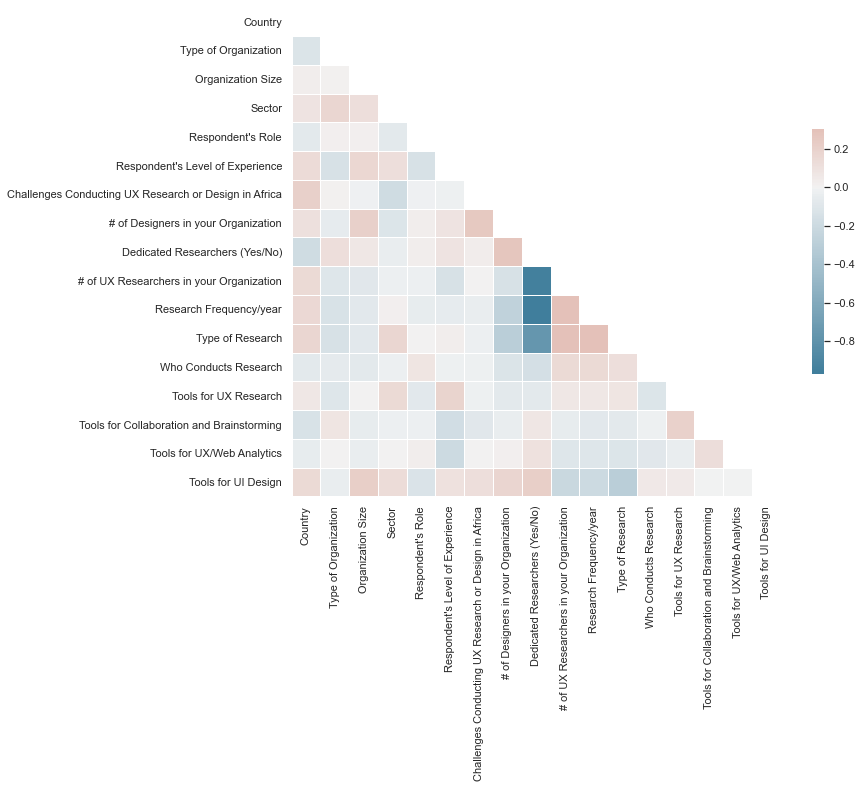

```python
from sklearn.preprocessing import LabelEncoder
import numpy as np

# Remove columsn with multiple values from original dataframe
df3_dropped = df.drop(ignore_cols, axis=1)

df3_filled = df3_dropped.fillna('UNK')


df3_final = df3_filled.copy()

for col in df3_final.columns:
  df3_final[col] = df3_final[col].astype('category')
  df3_final[col] = df3_final[col].cat.codes

df3_final.head()

import seaborn as sns

sns.set_theme(style="white")
corr = df3_final.corr()
mask = np.triu(np.ones_like(corr, dtype=bool))
f, ax = plt.subplots(figsize=(11, 9))
cmap = sns.diverging_palette(230, 20, as_cmap=True)

sns.heatmap(corr, mask=mask, cmap=cmap, vmax=.3, center=0,
            square=True, linewidths=.5, cbar_kws={"shrink": .5})

df3_final.corr()
```